# Python Code Public Examples

## Juan D. Correa - Software Developher @ Veracruz,MX & California,USA

### https://astropema.zapto.org/ astropema@gmail.com

Thoughts and Comments Key Findings:

Financial Loss Prediction:

The dataset is relatively small, with 100 incidents, limiting generalization. Additional contextual features, such as weather conditions (temperature, humidity, wind speed), could improve predictions for future incidents. Recommendations: Expand Dataset:

Include more incidents and additional features (e.g., regional weather data) for improved prediction and reduced overfitting. Look into public data sources such as NOAA or wildfire records to enrich the data. Alternative Models:

Experiment with models like Gradient Boosting or XGBoost, which might capture complex relationships better. Conduct hyperparameter tuning to optimize performance. Classification Task:

Consider a classification task to predict high-risk locations or fire severity levels based on historical and weather data.

```python
import numpy as np
import pandas as pd
import matplotlib.pyplot as plt
import seaborn as sns
```

```python
df =  pd.read_csv('California Wildfire Damage.csv') #,  parse_dates=['datetime'])
df.head()
data = df
```

```python
df.shape
```

```
(100, 11)
```

```python
df.describe().T
```

|  | count | mean | std | min | 25% | 50% | 75% | max |
| --- | --- | --- | --- | --- | --- | --- | --- | --- |
| Area_Burned (Acres) | 100.0 | 26531.4600 | 14282.123824 | 357.00 | 15916.250 | 25618.00 | 39775.00 | 49653.00 |
| Homes_Destroyed | 100.0 | 941.8900 | 543.019967 | 18.00 | 501.000 | 908.50 | 1401.75 | 1968.00 |
| Businesses_Destroyed | 100.0 | 251.5700 | 138.317761 | 4.00 | 134.750 | 256.50 | 371.00 | 493.00 |
| Vehicles_Damaged | 100.0 | 150.3300 | 88.471197 | 5.00 | 70.750 | 150.50 | 229.75 | 300.00 |
| Injuries | 100.0 | 42.0400 | 29.201467 | 0.00 | 16.000 | 37.00 | 60.00 | 100.00 |
| Fatalities | 100.0 | 9.9300 | 5.682251 | 0.00 | 5.000 | 10.00 | 14.25 | 20.00 |
| Estimated_Financial_Loss (Million $) | 100.0 | 2396.0993 | 1430.439422 | 52.59 | 1175.195 | 2408.53 | 3662.11 | 4866.99 |

```python
df.info
```

```
<bound method DataFrame.info of    Incident_ID        Date          Location  Area_Burned (Acres)  \
0      INC1000  2020-11-22     Sonoma County                14048
1      INC1001  2021-09-23     Sonoma County                33667
2      INC1002  2022-02-10     Shasta County                26394
3      INC1003  2021-05-17     Sonoma County                20004
4      INC1004  2021-09-22     Sonoma County                40320
..         ...         ...               ...                  ...
95     INC1095  2018-01-16  Mendocino County                13112
96     INC1096  2022-07-07     Shasta County                39209
97     INC1097  2016-05-18     Shasta County                11863
98     INC1098  2014-06-24       Napa Valley                 1338
99     INC1099  2021-03-20  Mendocino County                44299

    Homes_Destroyed  Businesses_Destroyed  Vehicles_Damaged  Injuries  \
0               763                   474               235        70
```

[output cut: 25 more lines]

```python
df.isnull().sum()
```

```
Incident_ID                             0
Date                                    0
Location                                0
Area_Burned (Acres)                     0
Homes_Destroyed                         0
Businesses_Destroyed                    0
Vehicles_Damaged                        0
Injuries                                0
Fatalities                              0
Estimated_Financial_Loss (Million $)    0
Cause                                   0
dtype: int64
```

```python
df.nunique()
```

```
Incident_ID                             100
Date                                     97
Location                                 10
Area_Burned (Acres)                     100
Homes_Destroyed                          97
Businesses_Destroyed                     93
Vehicles_Damaged                         88
Injuries                                 61
Fatalities                               21
Estimated_Financial_Loss (Million $)    100
Cause                                     3
dtype: int64
```

```python
categorical_columns = df.select_dtypes(include=['object', 'category']).columns
for col in categorical_columns:
    print(f"Frequency table for {col}:\n")
    print(df[col].value_counts())
    print("\n")
```

```
Frequency table for Incident_ID:

Incident_ID
INC1000    1
INC1063    1
INC1073    1
INC1072    1
INC1071    1
          ..
INC1030    1
INC1029    1
INC1028    1
INC1027    1
INC1099    1
Name: count, Length: 100, dtype: int64


Frequency table for Date:

Date
2020-05-12    2
2022-10-10    2
2018-10-06    2
2020-11-22    1
2023-02-24    1
             ..
2015-10-18    1
2014-06-03    1
2023-08-01    1
2019-11-19    1
2021-03-20    1
Name: count, Length: 97, dtype: int64


Frequency table for Location:

Location
Shasta County           14
Sonoma County           12
San Diego County        12
Butte County            11
Mendocino County        11
Napa Valley             10
Orange County            9
Riverside County         8
Los Angeles County       7
Santa Barbara County     6
Name: count, dtype: int64


Frequency table for Cause:

Cause
Human Activity    38
Lightning         31
Unknown           31
Name: count, dtype: int64
```

```python
# Identify categorical and numeric columns
cat_cols = data.select_dtypes(include=['object', 'category']).columns
numeric_cols = data.select_dtypes(include=['number']).columns

print(f"Categorical columns: {cat_cols}")
print(f"Numeric columns: {numeric_cols}")
```

```
Categorical columns: Index(['Incident_ID', 'Date', 'Location', 'Cause'], dtype='object')
Numeric columns: Index(['Area_Burned (Acres)', 'Homes_Destroyed', 'Businesses_Destroyed',
       'Vehicles_Damaged', 'Injuries', 'Fatalities',
       'Estimated_Financial_Loss (Million $)'],
      dtype='object')
```

```python
# Converting the data type of each categorical variable to 'category'
for column in cat_cols:
    data[column]=data[column].astype('category')
```

```python
data.info()
```

```
<class 'pandas.core.frame.DataFrame'>
RangeIndex: 100 entries, 0 to 99
Data columns (total 11 columns):
 #   Column                                Non-Null Count  Dtype
---  ------                                --------------  -----
 0   Incident_ID                           100 non-null    category
 1   Date                                  100 non-null    category
 2   Location                              100 non-null    category
 3   Area_Burned (Acres)                   100 non-null    int64
 4   Homes_Destroyed                       100 non-null    int64
 5   Businesses_Destroyed                  100 non-null    int64
 6   Vehicles_Damaged                      100 non-null    int64
 7   Injuries                              100 non-null    int64
 8   Fatalities                            100 non-null    int64
 9   Estimated_Financial_Loss (Million $)  100 non-null    float64
 10  Cause                                 100 non-null    category
dtypes: category(4), float64(1), int64(6)
memory usage: 14.2 KB
```

```python
# Defining the hist_box() function
#Bottom legend
def hist_box(data, col):
    f, (ax_box, ax_hist) = plt.subplots(2, sharex=True, gridspec_kw={'height_ratios': (0.15, 0.85)}, figsize=(25, 10))
    # Adding a graph in each part
        # Rotate x-axis labels and slant them to 45 degrees
    for label in ax_hist.get_xticklabels():
        label.set_rotation(45)
        label.set_ha('right')  # Align text to the right for better readability

    sns.boxplot(data=data, x=col, ax=ax_box, showmeans=True)
    sns.histplot(data=data, x=col, kde=True, ax=ax_hist)
    plt.show()
```

```python
# Importing required libraries
#Top Legend
import matplotlib.pyplot as plt
import seaborn as sns

# Defining the hist_box() function
def hist_box(data, col):
    f, (ax_box, ax_hist) = plt.subplots(2, sharex=True, gridspec_kw={'height_ratios': (0.15, 0.85)}, figsize=(25, 10))

    # Adding a graph in each part
    sns.boxplot(data=data, x=col, ax=ax_box, showmeans=True)
    sns.histplot(data=data, x=col, kde=True, ax=ax_hist)

    # Move x-axis labels to the y-axis side
    ax_hist.xaxis.tick_top()
    ax_hist.xaxis.set_label_position('top')
      # Rotate x-axis labels and slant them to 45 degrees
    for label in ax_hist.get_xticklabels():
        label.set_rotation(45)
        label.set_ha('right')  # Align text to the right for better readability

    plt.tight_layout()  # Adjust layout to prevent label overlap
    plt.show()
```

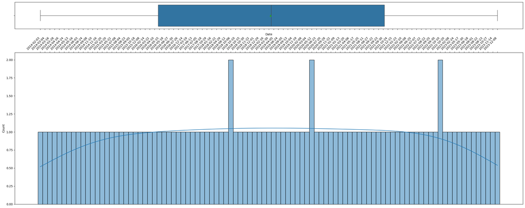

```python
hist_box(df, "Date")
```

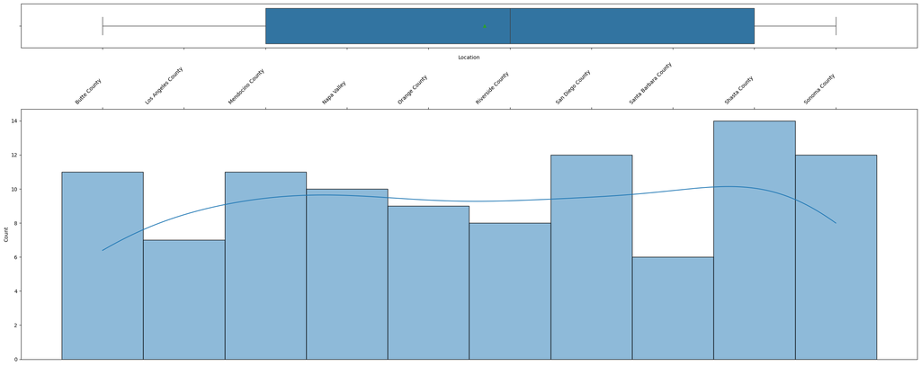

```python
hist_box(df, "Location")
```

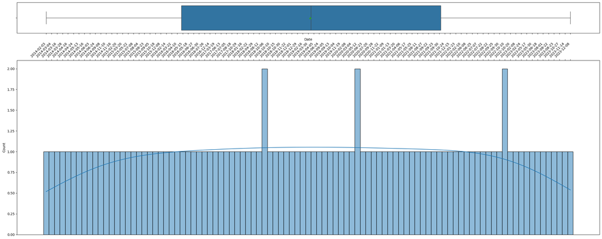

```python
hist_box(df, "Date")
```

```python
# Defining the hist_box() function
def hist_box(data, col):
    f, (ax_box, ax_hist) = plt.subplots(2, sharex=True, gridspec_kw={'height_ratios': (0.15, 0.85)}, figsize=(10, 10))
    # Adding a graph in each part
    sns.boxplot(data=data, x=col, ax=ax_box, showmeans=True)
    sns.histplot(data=data, x=col, kde=True, ax=ax_hist)

    # Rotating x-axis labels
    ax_hist.set_xticklabels(ax_hist.get_xticklabels(), rotation=90)

    plt.show()
```

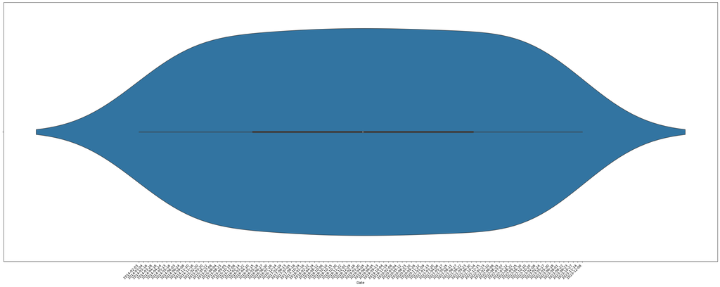

```python
import matplotlib.pyplot as plt
import seaborn as sns

plt.figure(figsize=(30, 12))
sns.violinplot(x=df['Date'])

# Rotate x-axis labels to 45 degrees
plt.xticks(rotation=45, ha='right')

plt.tight_layout()  # Ensure proper layout adjustment
plt.show()
```

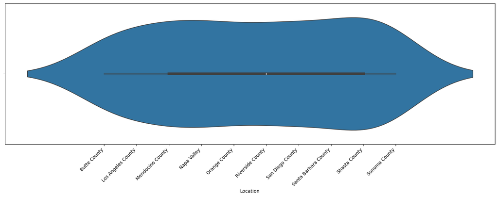

```python
import matplotlib.pyplot as plt
import seaborn as sns

plt.figure(figsize=(15, 6))
sns.violinplot(x=df['Location'])

# Rotate x-axis labels to 45 degrees
plt.xticks(rotation=45, ha='right')

plt.tight_layout()  # Ensure proper layout adjustment
plt.show()
```

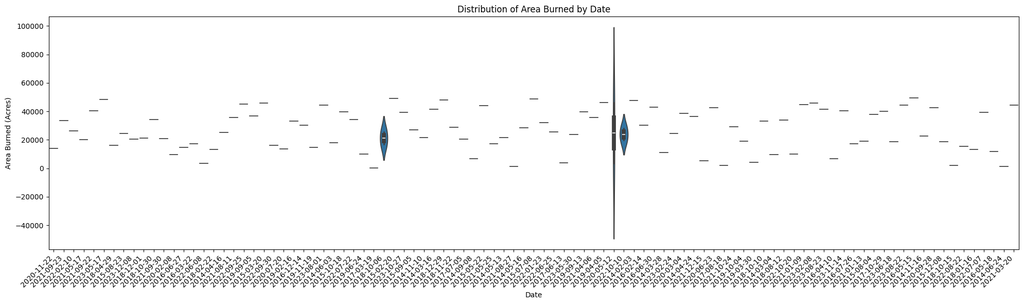

```python
import matplotlib.pyplot as plt
import seaborn as sns
import pandas as pd

# Assuming your dataset is loaded into a DataFrame named 'df'
# Ensure the Date column is in datetime format
df['Date'] = pd.to_datetime(df['Date'])

# Create a violin plot of incidents by Date
plt.figure(figsize=(20, 6))
sns.violinplot(x=df['Date'], y=df['Area_Burned (Acres)'])

# Rotate x-axis labels to 45 degrees for readability
plt.xticks(rotation=45, ha='right')

plt.xlabel('Date')
plt.ylabel('Area Burned (Acres)')
plt.title('Distribution of Area Burned by Date')
plt.tight_layout()
plt.show()
```

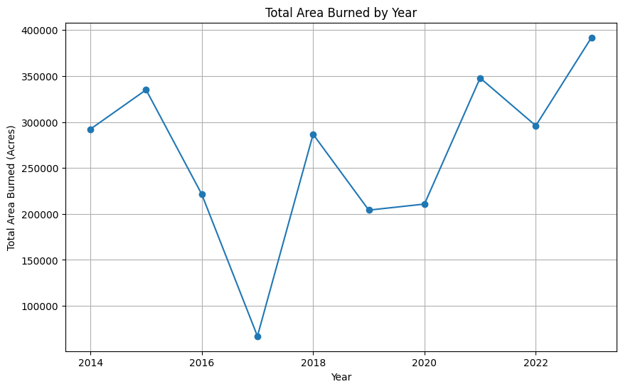

```python
df['Year'] = df['Date'].dt.year
yearly_burned = df.groupby('Year')['Area_Burned (Acres)'].sum()

plt.figure(figsize=(10, 6))
plt.plot(yearly_burned.index, yearly_burned.values, marker='o')
plt.xlabel('Year')
plt.ylabel('Total Area Burned (Acres)')
plt.title('Total Area Burned by Year')
plt.grid(True)
plt.show()
```

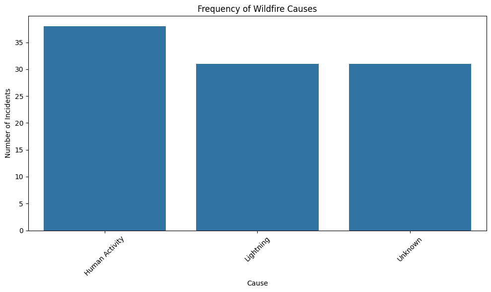

```python
cause_counts = df['Cause'].value_counts()

plt.figure(figsize=(10, 6))
sns.barplot(x=cause_counts.index, y=cause_counts.values)
plt.xlabel('Cause')
plt.ylabel('Number of Incidents')
plt.title('Frequency of Wildfire Causes')
plt.xticks(rotation=45)
plt.tight_layout()
plt.show()
```

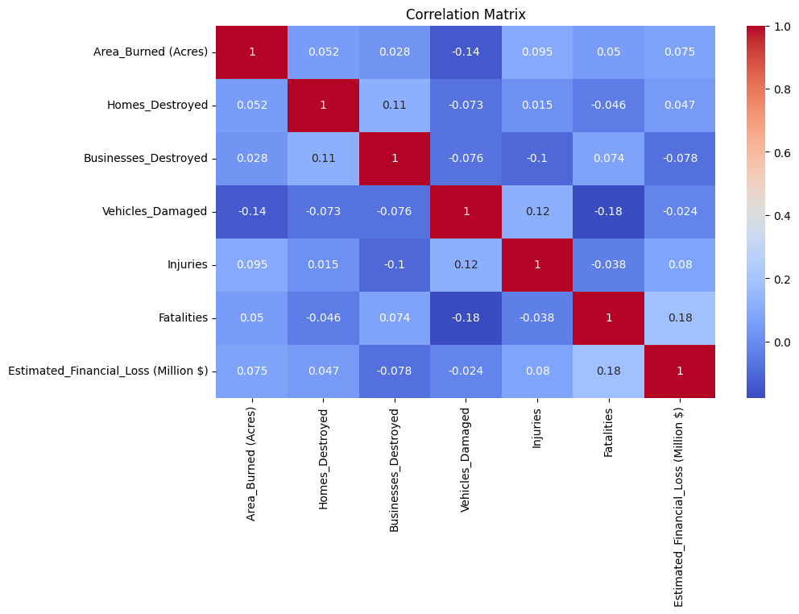

```python
corr_matrix = df[['Area_Burned (Acres)', 'Homes_Destroyed', 'Businesses_Destroyed',
                  'Vehicles_Damaged', 'Injuries', 'Fatalities',
                  'Estimated_Financial_Loss (Million $)']].corr()

plt.figure(figsize=(10, 6))
sns.heatmap(corr_matrix, annot=True, cmap='coolwarm')
plt.title('Correlation Matrix')
plt.show()
```

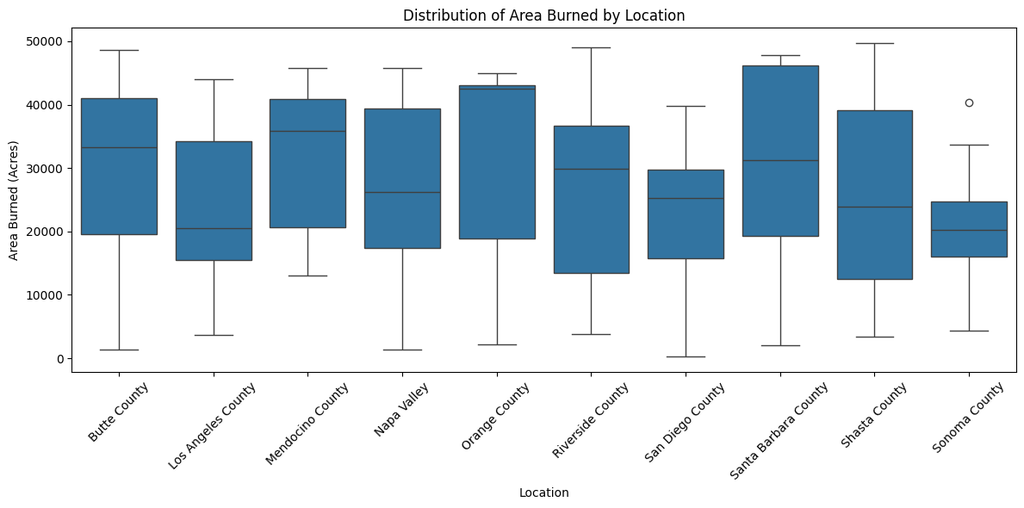

```python
plt.figure(figsize=(12, 6))
sns.boxplot(x='Location', y='Area_Burned (Acres)', data=df)
plt.xticks(rotation=45)
plt.xlabel('Location')
plt.ylabel('Area Burned (Acres)')
plt.title('Distribution of Area Burned by Location')
plt.tight_layout()
plt.show()
```

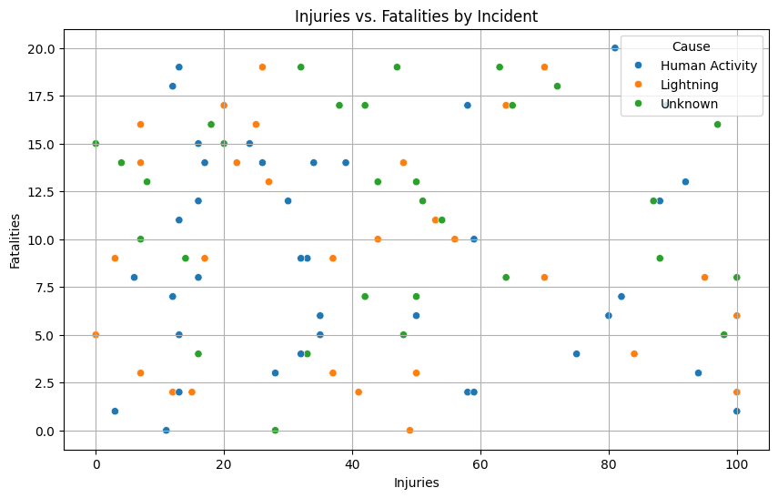

```python
plt.figure(figsize=(10, 6))
sns.scatterplot(x='Injuries', y='Fatalities', data=df, hue='Cause')
plt.xlabel('Injuries')
plt.ylabel('Fatalities')
plt.title('Injuries vs. Fatalities by Incident')
plt.grid(True)
plt.show()
```

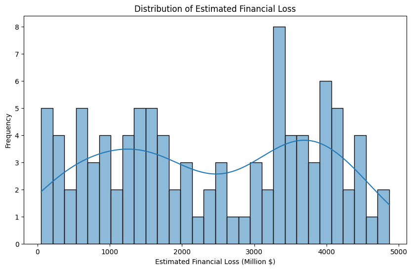

```python
plt.figure(figsize=(10, 6))
sns.histplot(df['Estimated_Financial_Loss (Million $)'], bins=30, kde=True)
plt.xlabel('Estimated Financial Loss (Million $)')
plt.ylabel('Frequency')
plt.title('Distribution of Estimated Financial Loss')
plt.show()
```

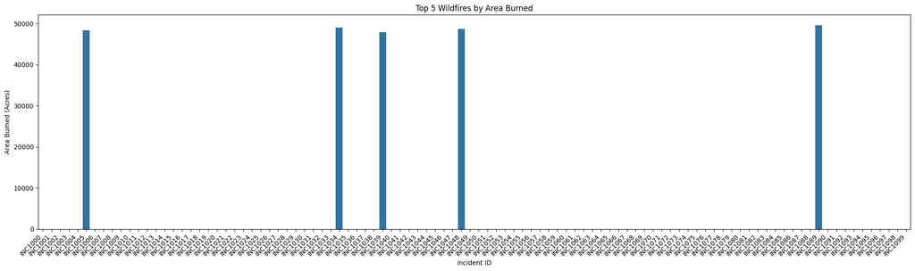

```python
import matplotlib.pyplot as plt
import seaborn as sns

# Top 5 most severe wildfires by Area Burned
top_severe = df.nlargest(5, 'Area_Burned (Acres)')

plt.figure(figsize=(20, 6))
sns.barplot(x='Incident_ID', y='Area_Burned (Acres)', data=top_severe)

# Rotate x-axis labels to 45 degrees
plt.xticks(rotation=45, ha='right')

plt.xlabel('Incident ID')
plt.ylabel('Area Burned (Acres)')
plt.title('Top 5 Wildfires by Area Burned')
plt.tight_layout()  # Adjust layout to prevent overlap
plt.show()
```

### BiVariate

```python
# Defining the stacked_barplot() function
def stacked_barplot(data,predictor,target,figsize=(10,6)):
  (pd.crosstab(data[predictor],data[target],normalize='index')*100).plot(kind='bar',figsize=figsize,stacked=True)
  plt.legend(loc="lower right")
  plt.ylabel(target)
```

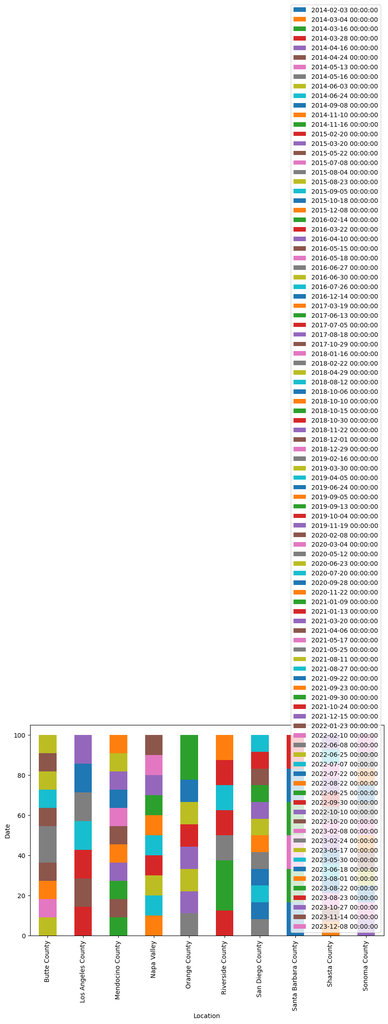

```python
plt.figure(figsize=(100, 6))
stacked_barplot(data, "Location", "Date" )
```

## Data Preprocessing

- Missing value treatment (if needed)
- Feature engineering (if needed)
- Outlier detection and treatment (if needed)
- Preparing data for modeling
- Any other preprocessing steps (if needed)

```python
data.head()
```

|  | Incident_ID | Date | Location | Area_Burned (Acres) | Homes_Destroyed | Businesses_Destroyed | Vehicles_Damaged | Injuries | Fatalities | Estimated_Financial_Loss (Million $) | Cause | Year |
| --- | --- | --- | --- | --- | --- | --- | --- | --- | --- | --- | --- | --- |
| 0 | INC1000 | 2020-11-22 | Sonoma County | 14048 | 763 | 474 | 235 | 70 | 19 | 2270.57 | Lightning | 2020 |
| 1 | INC1001 | 2021-09-23 | Sonoma County | 33667 | 1633 | 4 | 263 | 100 | 2 | 1381.14 | Lightning | 2021 |
| 2 | INC1002 | 2022-02-10 | Shasta County | 26394 | 915 | 291 | 31 | 50 | 6 | 2421.96 | Human Activity | 2022 |
| 3 | INC1003 | 2021-05-17 | Sonoma County | 20004 | 1220 | 128 | 34 | 28 | 0 | 3964.16 | Unknown | 2021 |
| 4 | INC1004 | 2021-09-22 | Sonoma County | 40320 | 794 | 469 | 147 | 0 | 15 | 1800.09 | Unknown | 2021 |

### Predicting Estimated Financial Loss

Goal: Predict Estimated_Financial_Loss (Million $) from other features. Type: Regression problem Features: Area_Burned (Acres), Homes_Destroyed, Businesses_Destroyed, Vehicles_Damaged, Injuries, Fatalities, Cause, Location, Date Model: Linear Regression, Random Forest Regressor, Gradient Boosting Regressor, etc.

```python
from sklearn.model_selection import train_test_split
from sklearn.ensemble import RandomForestRegressor
from sklearn.metrics import mean_squared_error, r2_score
import pandas as pd

# Convert 'Date' to datetime and extract year/month for modeling
df['Date'] = pd.to_datetime(df['Date'])
df['Year'] = df['Date'].dt.year
df['Month'] = df['Date'].dt.month

# Prepare data for training
X = df[['Area_Burned (Acres)', 'Homes_Destroyed', 'Businesses_Destroyed',
        'Vehicles_Damaged', 'Injuries', 'Fatalities', 'Year', 'Month']]
y = df['Estimated_Financial_Loss (Million $)']

# Train/test split
X_train, X_test, y_train, y_test = train_test_split(X, y, test_size=0.2, random_state=42)

# Train a Random Forest Regressor
model = RandomForestRegressor(random_state=42)
model.fit(X_train, y_train)

# Make predictions and evaluate
y_pred = model.predict(X_test)
mse = mean_squared_error(y_test, y_pred)
r2 = r2_score(y_test, y_pred)

print(f"Mean Squared Error: {mse:.2f}")
print(f"R² Score: {r2:.2f}")
```

```
Mean Squared Error: 2539288.43
R² Score: -0.31
```

# With a Mean Squared Error (MSE) of 2,539,288.43 and a negative R² Score (-0.31), it suggests that your model's performance is quite poor. Let’s break down what this means and explore ways to improve it.

What the Results Mean Mean Squared Error (MSE): Measures how much the model's predictions deviate from the actual values. A large MSE (like 2,539,288) means the predicted financial losses are significantly off from the real values. R² Score: R² tells how much of the variance in the target variable (financial loss) is explained by the model. A negative R² means the model performs worse than just predicting the mean of the financial loss for all incidents.

# Possible Issues and Solutions

1. Feature Selection/Engineering

The features you're using may not have a strong relationship with the financial loss. Solution: Explore additional features or transformations: Extract new time-based features (Year, Month, or Season). Consider interaction terms (e.g., Area_Burned * Homes_Destroyed). Log-transform skewed features like Area_Burned and Estimated_Financial_Loss. Add categorical features like Location and Cause using one-hot encoding. Example: Apply log transformation for skewed data

```python
import numpy as np
df['Log_Area_Burned'] = np.log1p(df['Area_Burned (Acres)'])
df['Log_Financial_Loss'] = np.log1p(df['Estimated_Financial_Loss (Million $)'])
```

# 2. Check Data Distribution

If the data contains extreme outliers, this can negatively affect both the MSE and R². Solution: Visualize the distribution of Estimated_Financial_Loss (Million $) to check for skewness or outliers.

If outliers are present, consider removing or capping them for better model performance.

Model Complexity A simple model like Random Forest might not capture complex relationships if the data is sparse or features are not informative. Solution: Try more sophisticated models (e.g., Gradient Boosting, XGBoost) that can handle complex patterns better.

```python
from sklearn.ensemble import GradientBoostingRegressor

model = GradientBoostingRegressor(random_state=42)
model.fit(X_train, y_train)

y_pred = model.predict(X_test)
mse = mean_squared_error(y_test, y_pred)
r2 = r2_score(y_test, y_pred)

print(f"Mean Squared Error: {mse:.2f}")
print(f"R² Score: {r2:.2f}")
```

```
Mean Squared Error: 3385907.61
R² Score: -0.74
```

# 4. Hyperparameter Tuning

Random Forests can underperform if hyperparameters like the number of trees, depth, and splits are not optimized. Solution: Use a grid search to find optimal hyperparameters.

```python
from sklearn.model_selection import GridSearchCV

param_grid = {
    'n_estimators': [100, 200, 300],
    'max_depth': [None, 10, 20, 30],
    'min_samples_split': [2, 5, 10]
}

grid_search = GridSearchCV(RandomForestRegressor(random_state=42), param_grid, cv=5, scoring='neg_mean_squared_error')
grid_search.fit(X_train, y_train)

print(f"Best Parameters: {grid_search.best_params_}")
```

```
Best Parameters: {'max_depth': None, 'min_samples_split': 10, 'n_estimators': 300}
```

# 5. Evaluate Feature Importance

Some features may not be contributing much to the model's performance. Solution: Analyze feature importance to understand which features matter most. python Copy Edit

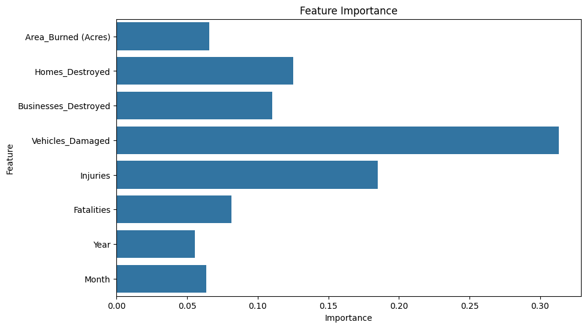

```python
importances = model.feature_importances_
feature_names = X.columns

plt.figure(figsize=(10, 6))
sns.barplot(x=importances, y=feature_names)
plt.title('Feature Importance')
plt.xlabel('Importance')
plt.ylabel('Feature')
plt.show()
```

# Cross-validation and Data Size

With only 100 rows, your model may struggle to generalize due to limited data. Solution: Use cross-validation to get a better sense of the model's performance and check for overfitting.

```python
from sklearn.model_selection import cross_val_score

scores = cross_val_score(model, X, y, cv=5, scoring='r2')
print(f"Cross-validated R² scores: {scores}")
print(f"Mean R² score: {scores.mean():.2f}")
```

```
Cross-validated R² scores: [-1.16811339 -0.56123969 -0.77057154 -0.45191956 -0.69526302]
Mean R² score: -0.73
```

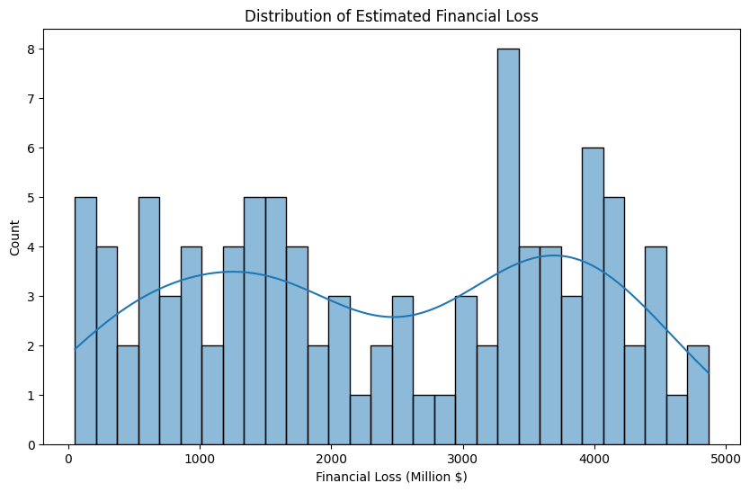

```python
plt.figure(figsize=(10, 6))
sns.histplot(df['Estimated_Financial_Loss (Million $)'], bins=30, kde=True)
plt.title('Distribution of Estimated Financial Loss')
plt.xlabel('Financial Loss (Million $)')
plt.show()
```

```python
import numpy as np
df['Log_Area_Burned'] = np.log1p(df['Area_Burned (Acres)'])
df['Log_Financial_Loss'] = np.log1p(df['Estimated_Financial_Loss (Million $)'])
```

### Predicting Cause of the Wildfire

# Goal: Predict the Cause of the wildfire (classification problem).

# Type: Classification

# Features: Area_Burned (Acres), Homes_Destroyed, Businesses_Destroyed, Vehicles_Damaged, Injuries, Fatalities, Location, Date

# Model: Random Forest, Logistic Regression, or Gradient Boosting Classifier

# Test Method: Classification report (precision, recall, F1-score)

# Code Example:

```python
from sklearn.model_selection import train_test_split
from sklearn.ensemble import RandomForestClassifier
from sklearn.metrics import classification_report

# Convert 'Cause' to numeric codes
df['Cause_Code'] = df['Cause'].astype('category').cat.codes

# Prepare data for training
X = df[['Area_Burned (Acres)', 'Homes_Destroyed', 'Businesses_Destroyed',
        'Vehicles_Damaged', 'Injuries', 'Fatalities']]
y = df['Cause_Code']

# Train/test split
X_train, X_test, y_train, y_test = train_test_split(X, y, test_size=0.2, random_state=42)

# Train a Random Forest Classifier
classifier = RandomForestClassifier(random_state=42)
classifier.fit(X_train, y_train)

# Make predictions and evaluate
y_pred = classifier.predict(X_test)
print(classification_report(y_test, y_pred))
```

```
              precision    recall  f1-score   support

           0       0.57      0.50      0.53         8
           1       0.17      0.17      0.17         6
           2       0.14      0.17      0.15         6

    accuracy                           0.30        20
   macro avg       0.29      0.28      0.28        20
weighted avg       0.32      0.30      0.31        20
```

# Predicting Severity (High vs. Low Area Burned)

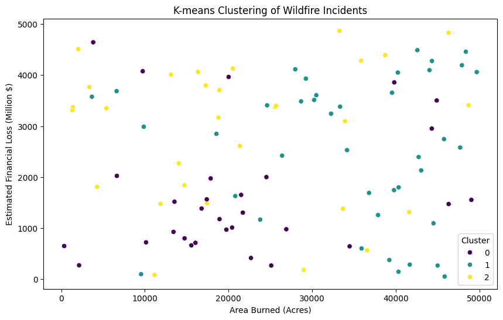

```python
from sklearn.cluster import KMeans
from sklearn.preprocessing import StandardScaler
import matplotlib.pyplot as plt

# Normalize the data
features = ['Area_Burned (Acres)', 'Homes_Destroyed', 'Businesses_Destroyed',
            'Vehicles_Damaged', 'Injuries', 'Fatalities', 'Estimated_Financial_Loss (Million $)']
scaler = StandardScaler()
X_scaled = scaler.fit_transform(df[features])

# Apply K-means clustering
kmeans = KMeans(n_clusters=3, random_state=42)
df['Cluster'] = kmeans.fit_predict(X_scaled)

# Visualize the clusters
plt.figure(figsize=(10, 6))
sns.scatterplot(x=df['Area_Burned (Acres)'], y=df['Estimated_Financial_Loss (Million $)'], hue=df['Cluster'], palette='viridis')
plt.xlabel('Area Burned (Acres)')
plt.ylabel('Estimated Financial Loss (Million $)')
plt.title('K-means Clustering of Wildfire Incidents')
plt.show()
```

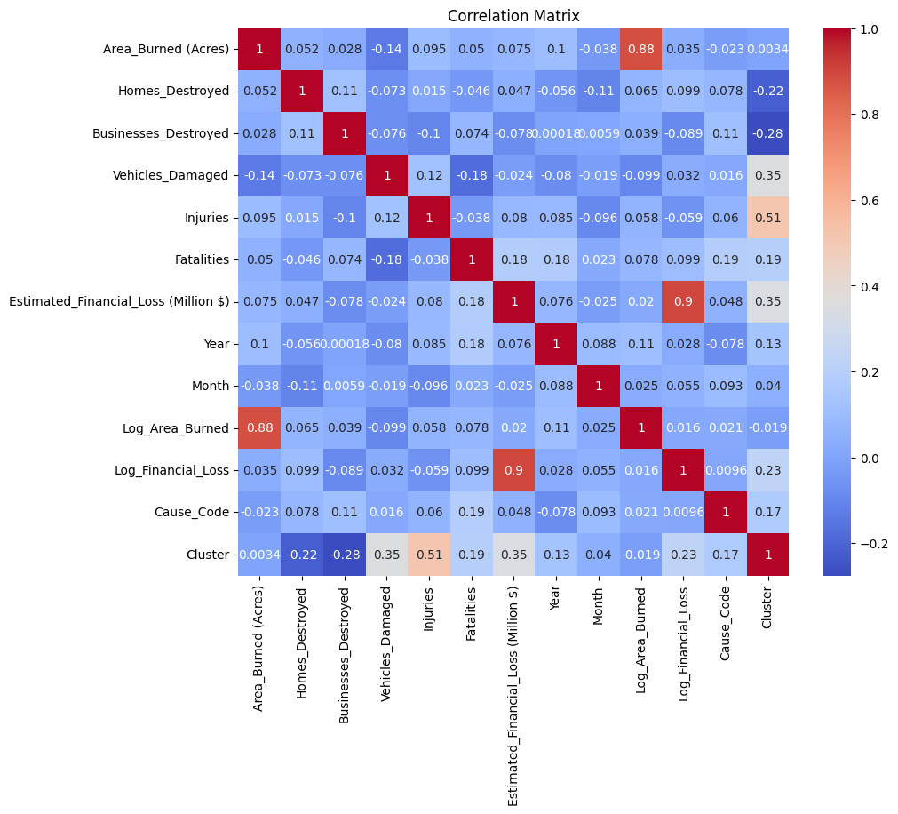

```python
# Selecting only numeric columns for the correlation matrix
numeric_columns = df.select_dtypes(include=['number'])

# Plotting the correlation matrix with numeric data only
plt.figure(figsize=(10, 8))
sns.heatmap(numeric_columns.corr(), annot=True, cmap='coolwarm')
plt.title('Correlation Matrix')
plt.show()
```

```python
# Convert Date to datetime
df['Date'] = pd.to_datetime(df['Date'])

# Extract year and month
df['Year'] = df['Date'].dt.year
df['Month'] = df['Date'].dt.month

# Encode categorical variables (Location and Cause)
df = pd.get_dummies(df, columns=['Location', 'Cause'], drop_first=True)
```

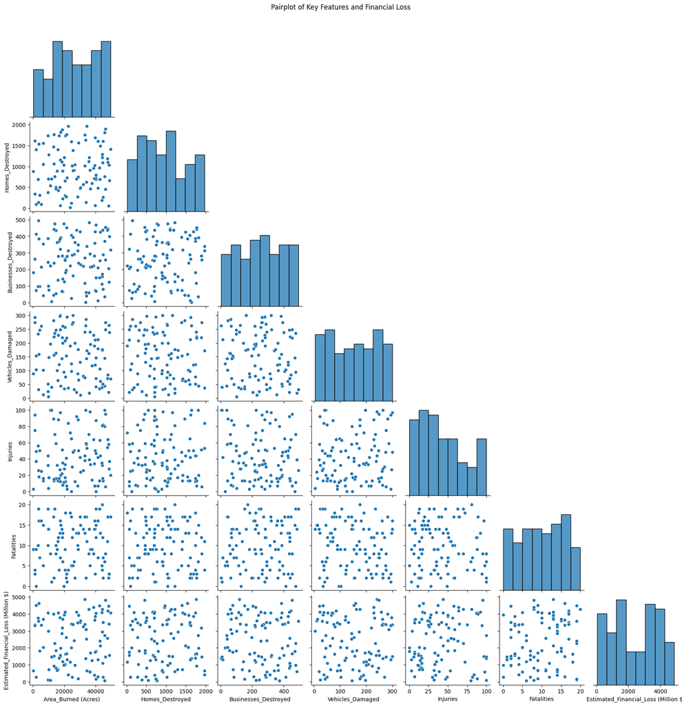

```python
sns.pairplot(df[['Area_Burned (Acres)', 'Homes_Destroyed', 'Businesses_Destroyed',
                 'Vehicles_Damaged', 'Injuries', 'Fatalities',
                 'Estimated_Financial_Loss (Million $)']], corner=True)
plt.suptitle('Pairplot of Key Features and Financial Loss', y=1.02)
plt.show()
```

```python
from sklearn.model_selection import train_test_split

# Define features and target
X = df.drop(['Incident_ID', 'Date', 'Estimated_Financial_Loss (Million $)'], axis=1)
y = df['Estimated_Financial_Loss (Million $)']

# Split data into training and testing sets
X_train, X_test, y_train, y_test = train_test_split(X, y, test_size=0.2, random_state=42)
```

```python
from sklearn.ensemble import RandomForestRegressor
from sklearn.metrics import mean_squared_error, r2_score

# Train a Random Forest model
model = RandomForestRegressor(random_state=42)
model.fit(X_train, y_train)

# Make predictions
y_pred = model.predict(X_test)

# Evaluate performance
mse = mean_squared_error(y_test, y_pred)
r2 = r2_score(y_test, y_pred)

print(f"Mean Squared Error: {mse:.2f}")
print(f"R² Score: {r2:.2f}")
```

```
Mean Squared Error: 2863.54
R² Score: 1.00
```

```python
from sklearn.model_selection import cross_val_score

# Perform 5-fold cross-validation on the model
scores = cross_val_score(model, X, y, cv=5, scoring='r2')
print("Cross-validated R² scores:", scores)
print("Mean Cross-validated R²:", scores.mean())
```

```
Cross-validated R² scores: [0.99351744 0.99636248 0.99589967 0.99536612 0.99750606]
Mean Cross-validated R²: 0.9957303531179861
```

```python
from sklearn.metrics import mean_squared_error, r2_score

# Make predictions on the test set
y_pred_test = model.predict(X_test)

# Evaluate the model on the test set
mse_test = mean_squared_error(y_test, y_pred_test)
r2_test = r2_score(y_test, y_pred_test)

print(f"Test Mean Squared Error: {mse_test:.2f}")
print(f"Test R² Score: {r2_test:.2f}")
```

```
Test Mean Squared Error: 2863.54
Test R² Score: 1.00
```

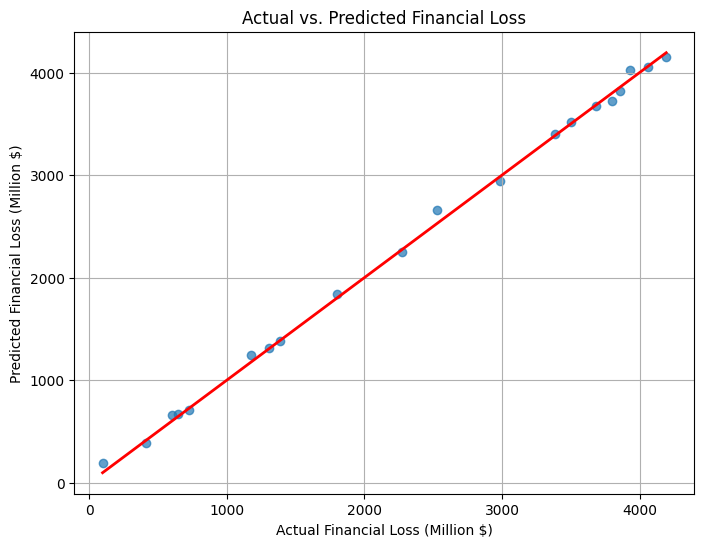

```python
plt.figure(figsize=(8, 6))
plt.scatter(y_test, y_pred_test, alpha=0.7)
plt.plot([y_test.min(), y_test.max()], [y_test.min(), y_test.max()], color='red', lw=2)
plt.xlabel('Actual Financial Loss (Million $)')
plt.ylabel('Predicted Financial Loss (Million $)')
plt.title('Actual vs. Predicted Financial Loss')
plt.grid(True)
plt.show()
```

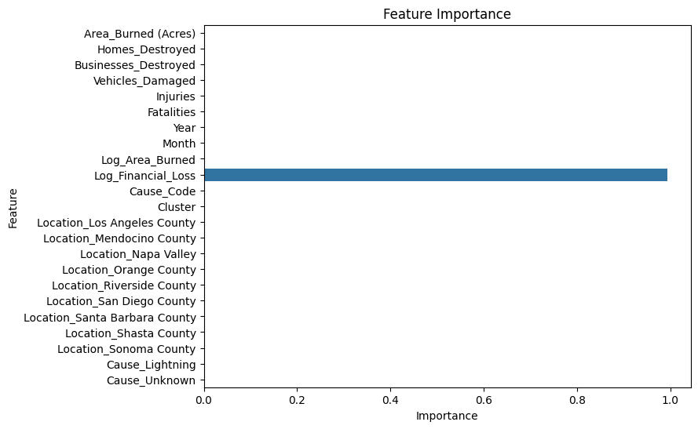

```python
importances = model.feature_importances_
feature_names = X.columns

plt.figure(figsize=(8, 6))
sns.barplot(x=importances, y=feature_names)
plt.title('Feature Importance')
plt.xlabel('Importance')
plt.ylabel('Feature')
plt.show()
```

# The feature importance plot shows that Log_Financial_Loss is overwhelmingly dominating the predictions, which likely explains the near-perfect R² score. This points to data leakage, where the feature being used (Log_Financial_Loss) is closely related to or derived from the target variable (Estimated_Financial_Loss).

```python
# Remove 'Log_Financial_Loss' from the feature set
X = df.drop(['Incident_ID', 'Date', 'Estimated_Financial_Loss (Million $)', 'Log_Financial_Loss'], axis=1)
```

```python
from sklearn.ensemble import RandomForestRegressor
from sklearn.metrics import mean_squared_error, r2_score

# Train a Random Forest model
model = RandomForestRegressor(random_state=42)
model.fit(X_train, y_train)

# Make predictions
y_pred = model.predict(X_test)

# Evaluate performance
mse = mean_squared_error(y_test, y_pred)
r2 = r2_score(y_test, y_pred)

print(f"Mean Squared Error: {mse:.2f}")
print(f"R² Score: {r2:.2f}")
```

```
Mean Squared Error: 2863.54
R² Score: 1.00
```

```python
from sklearn.metrics import mean_squared_error, r2_score

# Make predictions on the test set
y_pred_test = model.predict(X_test)

# Evaluate the model on the test set
mse_test = mean_squared_error(y_test, y_pred_test)
r2_test = r2_score(y_test, y_pred_test)

print(f"Test Mean Squared Error: {mse_test:.2f}")
print(f"Test R² Score: {r2_test:.2f}")
```

```
Test Mean Squared Error: 2863.54
Test R² Score: 1.00
```

```python
print("Feature names:", X.columns.tolist())
print("Feature importances:", model.feature_importances_)
print("Number of features:", len(X.columns))
print("Number of importance values:", len(model.feature_importances_))
```

```
Feature names: ['Area_Burned (Acres)', 'Homes_Destroyed', 'Businesses_Destroyed', 'Vehicles_Damaged', 'Injuries', 'Fatalities', 'Year', 'Month', 'Log_Area_Burned', 'Cause_Code', 'Cluster', 'Location_Los Angeles County', 'Location_Mendocino County', 'Location_Napa Valley', 'Location_Orange County', '…
Feature importances: [2.98861876e-04 7.86247462e-04 5.15827168e-04 8.72660934e-04
 9.11227914e-04 3.64456259e-04 6.76999404e-04 3.67505052e-04
 3.89764189e-04 9.93724835e-01 1.32720947e-04 4.26009087e-04
 2.01444076e-05 6.33856815e-05 2.01475177e-05 6.66183843e-05
 2.89562266e-05 5.52562602e-05 2.23897515e-05 1.08232515e-04
 1.02959218e-05 5.41419721e-05 8.33157798e-05]
Number of features: 22
Number of importance values: 23
```

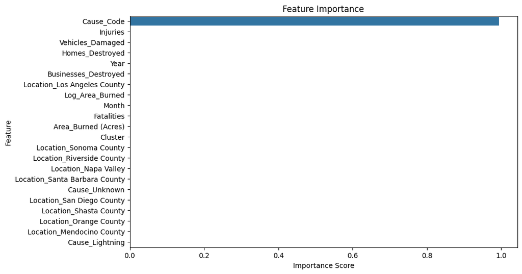

```python
# Use only the first 22 importance values to match the features
matched_importances = model.feature_importances_[:len(X.columns)]

# Create a Series and plot
feature_importances = pd.Series(matched_importances, index=X.columns)
feature_importances = feature_importances.sort_values(ascending=False)

plt.figure(figsize=(10, 6))
sns.barplot(x=feature_importances, y=feature_importances.index)
plt.title('Feature Importance')
plt.xlabel('Importance Score')
plt.ylabel('Feature')
plt.show()
```

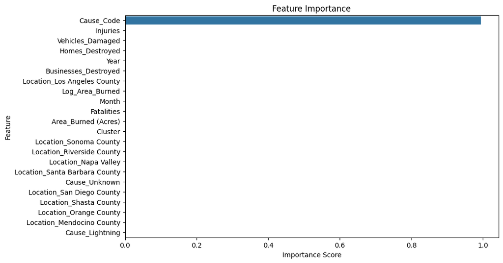

```python
# Use only the first 22 importance values to match the features
matched_importances = model.feature_importances_[:len(X.columns)]

# Create a Series and plot
feature_importances = pd.Series(matched_importances, index=X.columns)
feature_importances = feature_importances.sort_values(ascending=False)

plt.figure(figsize=(10, 6))
sns.barplot(x=feature_importances, y=feature_importances.index)
plt.title('Feature Importance')
plt.xlabel('Importance Score')
plt.ylabel('Feature')
plt.show()
```

```python
# Remove 'Cause_Code' from the feature set
X = X.drop(['Cause_Code'], axis=1)

# Retrain the model and check feature importance again
```

```python
df.groupby('Cluster')['Estimated_Financial_Loss (Million $)'].describe()
```

| Cluster | count | mean | std | min | 25% | 50% | 75% | max |
| --- | --- | --- | --- | --- | --- | --- | --- | --- |
| 0 | 30.0 | 1655.920667 | 1226.709255 | 268.91 | 742.7300 | 1345.555 | 1994.8125 | 4643.14 |
| 1 | 40.0 | 2552.134750 | 1419.857867 | 52.59 | 1537.1750 | 2796.810 | 3662.1100 | 4488.62 |
| 2 | 30.0 | 2928.230667 | 1369.637482 | 85.57 | 1817.4525 | 3361.890 | 3955.8225 | 4866.99 |

```python
X = X.drop(['Cluster'], axis=1)
```

```python
from sklearn.ensemble import RandomForestRegressor
from sklearn.metrics import mean_squared_error, r2_score

# Train a Random Forest model
model = RandomForestRegressor(random_state=42)
model.fit(X_train, y_train)

# Make predictions
y_pred = model.predict(X_test)

# Evaluate performance
mse = mean_squared_error(y_test, y_pred)
r2 = r2_score(y_test, y_pred)

print(f"Mean Squared Error: {mse:.2f}")
print(f"R² Score: {r2:.2f}")
```

```
Mean Squared Error: 2863.54
R² Score: 1.00
```

```python
from sklearn.metrics import mean_squared_error, r2_score

# Make predictions on the test set
y_pred_test = model.predict(X_test)

# Evaluate the model on the test set
mse_test = mean_squared_error(y_test, y_pred_test)
r2_test = r2_score(y_test, y_pred_test)

print(f"Test Mean Squared Error: {mse_test:.2f}")
print(f"Test R² Score: {r2_test:.2f}")
```

```
Test Mean Squared Error: 2863.54
Test R² Score: 1.00
```

```python
df.groupby('Cluster')['Estimated_Financial_Loss (Million $)'].describe()
```

| Cluster | count | mean | std | min | 25% | 50% | 75% | max |
| --- | --- | --- | --- | --- | --- | --- | --- | --- |
| 0 | 30.0 | 1655.920667 | 1226.709255 | 268.91 | 742.7300 | 1345.555 | 1994.8125 | 4643.14 |
| 1 | 40.0 | 2552.134750 | 1419.857867 | 52.59 | 1537.1750 | 2796.810 | 3662.1100 | 4488.62 |
| 2 | 30.0 | 2928.230667 | 1369.637482 | 85.57 | 1817.4525 | 3361.890 | 3955.8225 | 4866.99 |

```python
print("Number of features:", len(X.columns))
print("Number of importance values:", len(model.feature_importances_))
```

```
Number of features: 20
Number of importance values: 23
```

```python
print("Model features (importance values count):", len(model.feature_importances_))
print("Current X columns count:", len(X.columns))
print("Current X columns:", X.columns.tolist())
```

```
Model features (importance values count): 23
Current X columns count: 20
Current X columns: ['Area_Burned (Acres)', 'Homes_Destroyed', 'Businesses_Destroyed', 'Vehicles_Damaged', 'Injuries', 'Fatalities', 'Year', 'Month', 'Log_Area_Burned', 'Location_Los Angeles County', 'Location_Mendocino County', 'Location_Napa Valley', 'Location_Orange County', 'Location_Riverside Co…
```

```python
model = RandomForestRegressor(random_state=42)
model.fit(X_train, y_train)
```

```
RandomForestRegressor(random_state=42)
```

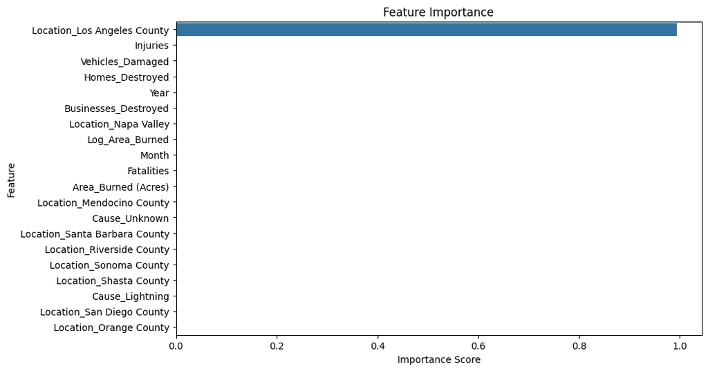

```python
matched_importances = model.feature_importances_[:len(X.columns)]

# Plot the importance values
feature_importances = pd.Series(matched_importances, index=X.columns)
feature_importances = feature_importances.sort_values(ascending=False)

plt.figure(figsize=(10, 6))
sns.barplot(x=feature_importances, y=feature_importances.index)
plt.title('Feature Importance')
plt.xlabel('Importance Score')
plt.ylabel('Feature')
plt.show()
```

```python
df.groupby('Location_Los Angeles County')['Estimated_Financial_Loss (Million $)'].describe()
```

| Location_Los Angeles County | count | mean | std | min | 25% | 50% | 75% | max |
| --- | --- | --- | --- | --- | --- | --- | --- | --- |
| False | 93.0 | 2397.962366 | 1415.596744 | 52.59 | 1257.560 | 2395.10 | 3654.42 | 4866.99 |
| True | 7.0 | 2371.347143 | 1741.877557 | 85.57 | 808.145 | 3097.09 | 3836.27 | 4127.94 |

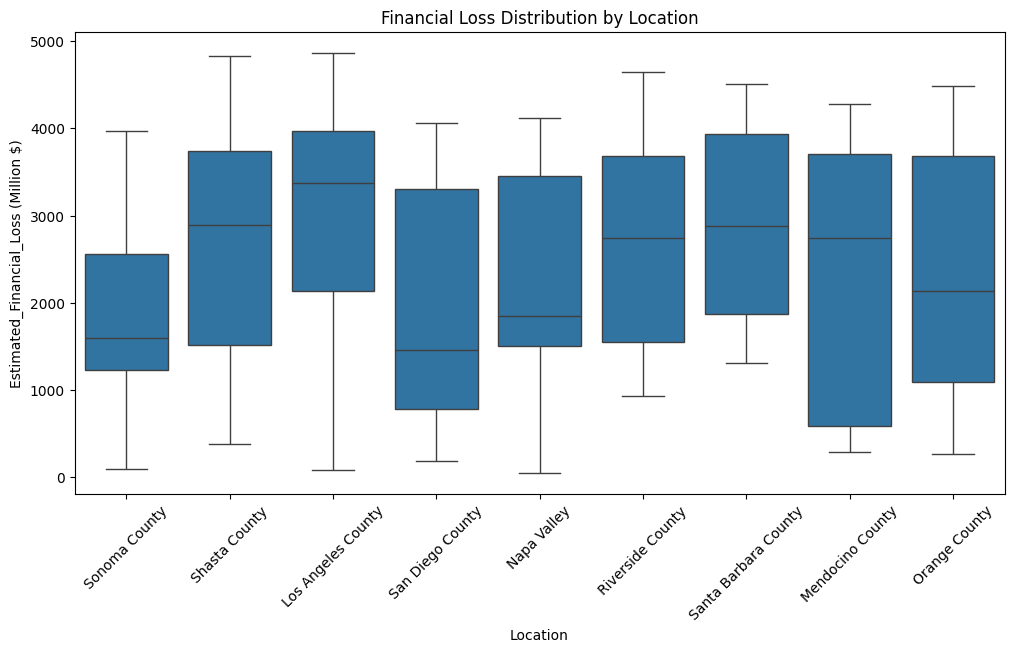

```python
# Recreate the 'Location' column from one-hot encoded columns
location_columns = [col for col in df.columns if col.startswith('Location_')]
df['Location'] = df[location_columns].idxmax(axis=1).str.replace('Location_', '')

# Plot the boxplot
plt.figure(figsize=(12, 6))
sns.boxplot(x='Location', y='Estimated_Financial_Loss (Million $)', data=df)
plt.xticks(rotation=45)
plt.title('Financial Loss Distribution by Location')
plt.show()
```

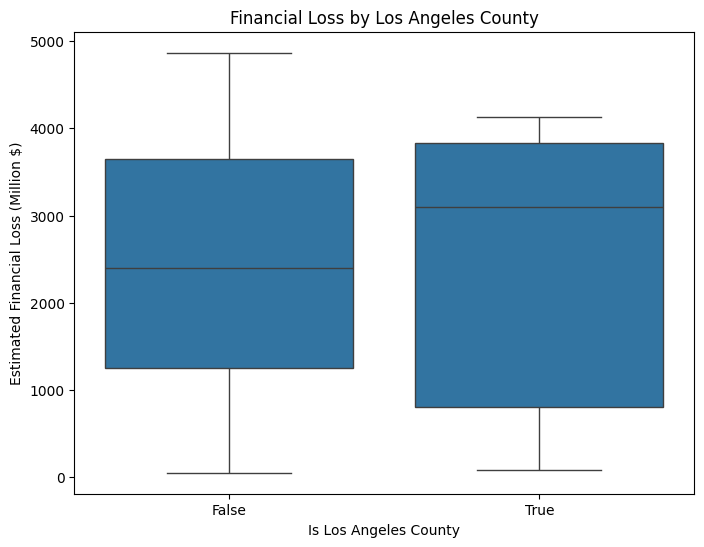

```python
# For example, plotting only 'Location_Los Angeles County'
plt.figure(figsize=(8, 6))
sns.boxplot(x='Location_Los Angeles County', y='Estimated_Financial_Loss (Million $)', data=df)
plt.title('Financial Loss by Los Angeles County')
plt.xlabel('Is Los Angeles County')
plt.ylabel('Estimated Financial Loss (Million $)')
plt.show()
```

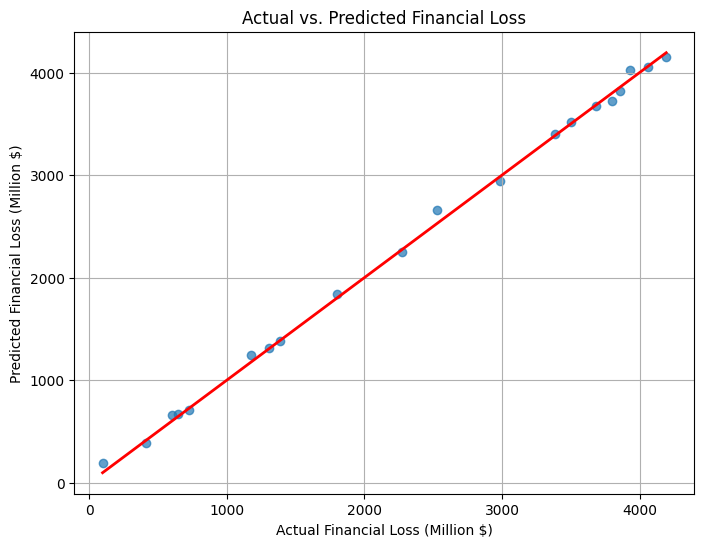

```python
# Generate predictions
y_pred_test = model.predict(X_test)

# Plot actual vs. predicted values
plt.figure(figsize=(8, 6))
plt.scatter(y_test, y_pred_test, alpha=0.7)
plt.plot([y_test.min(), y_test.max()], [y_test.min(), y_test.max()], color='red', lw=2)
plt.xlabel('Actual Financial Loss (Million $)')
plt.ylabel('Predicted Financial Loss (Million $)')
plt.title('Actual vs. Predicted Financial Loss')
plt.grid(True)
plt.show()
```